# Project_Machine_Learning

Sofia Coradini

27/08/2020

# Title: Prediction Assignment Writeup

## 1. Introduction

### 1.1. Observations

- The “pml-coursera-project.md” is a markdown file, created to aid the reviewers in taking a quick look in the analysis.
- The “pml-training.csv” and “pml-testing.csv” are the original data sets used for the analysis.
- The “testing.with.predictions” file contains a table with the “pml-testing.csv” data set observations along with the predictions performed by the Random Forest model of the analysis, for the variable classe.

## 2. Data Loading and Processing

### 2.1. Load package and set seed

```r
set.seed(12345)
library(knitr)
library(caret)
```

```r
library(rpart)
library(rpart.plot)
library(rattle)
library(randomForest)
library(corrplot)
```

### 2.2.Download raw data

```r
train_url <- "https://d396qusza40orc.cloudfront.net/predmachlearn/pml-training.csv"
train_data <- "pml-traininig.csv"

test_url <- "https://d396qusza40orc.cloudfront.net/predmachlearn/pml-testing.csv"
test_data <- "pml-testing.csv"
```

### 2.3. Download the datasets

```r
if(!file.exists(train_data))
{
    download.file(train_url,destfile = train_data)
}

training <- read.csv(train_data, stringsAsFactors = TRUE)

if(!file.exists(test_data))
{
    download.file(test_url,destfile = test_data)
}

testing  <- read.csv(test_data, stringsAsFactors = TRUE)
```

### 2.3. create a partition using caret with the training dataset on 70,30 ratio

```r
inTrain  <- createDataPartition(training$classe, p=0.7, list=FALSE)

set_train <- training[inTrain, ]

set_test  <- training[-inTrain, ]
```

### 2.4. Look the dataset

```r
dim(set_train)
```

```
## [1] 13737   160
```

```r
dim(set_test)
```

```
## [1] 5885  160
```

- Both created datasets have 160 variables.

### 2.5. Remove NA values and identification of variables

```r
NZV <- nearZeroVar(set_train)
TrainSet <- set_train[, -NZV]
TestSet  <- set_test[, -NZV]
dim(TestSet)
```

```
## [1] 5885  104
```

```r
dim(TrainSet)
```

```
## [1] 13737   104
```

```r
AllNA  <- sapply(TrainSet, function(x) mean(is.na(x))) > 0.95
trainset <- TrainSet[, AllNA==FALSE]
testset  <- TestSet[, AllNA==FALSE]
dim(trainset)
```

```
## [1] 13737    59
```

```r
dim(testset)
```

```
## [1] 5885   59
```

```r
train_s <- trainset[, -(1:5)]
test_s  <- testset[, -(1:5)]

dim(train_s)
```

```
## [1] 13737    54
```

```r
dim(test_s)
```

```
## [1] 5885   54
```

- Now we have just 54 variables.

## 3. Correction Analysis

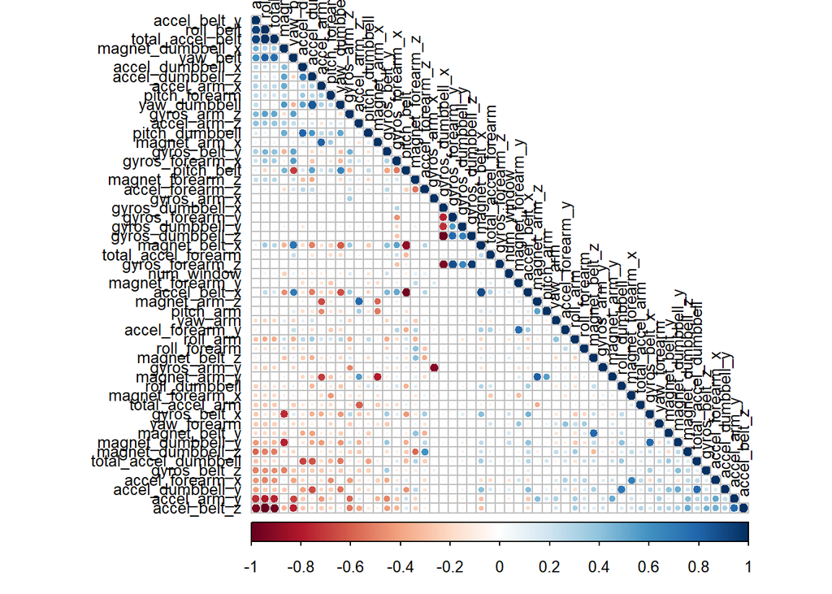

```r
corMatrix <- cor(train_s[, -54])
corrplot(corMatrix, order = "FPC", method = "circle", type = "lower",
         tl.cex = 0.8, tl.col = rgb(0, 0, 0))
```

## 4 Creating models

### 4.1. Random forest model

#### 4.1.1 Built the model

```r
set.seed(301)
control_rf <- trainControl(method="cv", number=3, verboseIter=FALSE)
mod_RF <- train(classe ~ ., data=train_s, method="rf",
                          trControl=control_rf)
pred_rf <- predict(mod_RF, test_s)
confusionMatrix(test_s$classe, pred_rf)
```

```
## Confusion Matrix and Statistics
##
##           Reference
## Prediction    A    B    C    D    E
##          A 1674    0    0    0    0
##          B    1 1138    0    0    0
##          C    0    2 1024    0    0
##          D    0    0    3  960    1
##          E    0    0    0    1 1081
##
## Overall Statistics
##
##                Accuracy : 0.9986
##                  95% CI : (0.9973, 0.9994)
##     No Information Rate : 0.2846
##     P-Value [Acc > NIR] : < 2.2e-16
##
##                   Kappa : 0.9983
##
##  Mcnemar's Test P-Value : NA
##
## Statistics by Class:
##
##                      Class: A Class: B Class: C Class: D Class: E
## Sensitivity            0.9994   0.9982   0.9971   0.9990   0.9991
## Specificity            1.0000   0.9998   0.9996   0.9992   0.9998
## Pos Pred Value         1.0000   0.9991   0.9981   0.9959   0.9991
## Neg Pred Value         0.9998   0.9996   0.9994   0.9998   0.9998
## Prevalence             0.2846   0.1937   0.1745   0.1633   0.1839
## Detection Rate         0.2845   0.1934   0.1740   0.1631   0.1837
## Detection Prevalence   0.2845   0.1935   0.1743   0.1638   0.1839
## Balanced Accuracy      0.9997   0.9990   0.9983   0.9991   0.9994
```

- The predictive accuracy of the Random Forest model is 99.8 %.

### 4.2. Decision tree

#### 4.2.1. Decision tree

[figure not shown]

```r
set.seed(1813)
fit_decision_tree <- rpart(classe ~ ., data = train_s, method="class")
fancyRpartPlot(fit_decision_tree)
```

#### 4.2.2. Building the model

```r
predict_decision_tree <- predict(fit_decision_tree, newdata = test_s, type="class")
conf_matrix_decision_tree <- confusionMatrix(predict_decision_tree, test_s$classe)
conf_matrix_decision_tree
```

```
## Confusion Matrix and Statistics
##
##           Reference
## Prediction    A    B    C    D    E
##          A 1502  201   59   66   74
##          B   58  660   37   64  114
##          C    4   66  815  129   72
##          D   90  148   54  648  126
##          E   20   64   61   57  696
##
## Overall Statistics
##
##                Accuracy : 0.7342
##                  95% CI : (0.7228, 0.7455)
##     No Information Rate : 0.2845
##     P-Value [Acc > NIR] : < 2.2e-16
##
##                   Kappa : 0.6625
##
##  Mcnemar's Test P-Value : < 2.2e-16
##
## Statistics by Class:
##
##                      Class: A Class: B Class: C Class: D Class: E
## Sensitivity            0.8973   0.5795   0.7943   0.6722   0.6433
## Specificity            0.9050   0.9425   0.9442   0.9151   0.9579
## Pos Pred Value         0.7897   0.7074   0.7505   0.6079   0.7751
## Neg Pred Value         0.9568   0.9033   0.9560   0.9344   0.9226
## Prevalence             0.2845   0.1935   0.1743   0.1638   0.1839
## Detection Rate         0.2552   0.1121   0.1385   0.1101   0.1183
## Detection Prevalence   0.3232   0.1585   0.1845   0.1811   0.1526
## Balanced Accuracy      0.9011   0.7610   0.8693   0.7936   0.8006
```

- The predictive accuracy of the decision tree model is 73.4 %.

### 4.3. LDA

```r
model_lda <- train(classe ~ ., data = train_s, method = "lda")
pred_lda <- predict(model_lda, test_s)
levels(model_lda)
```

```
## [1] "A" "B" "C" "D" "E"
```

```r
levels(testset$classe)
```

```
## [1] "A" "B" "C" "D" "E"
```

```r
confusionMatrix(test_s$classe, pred_lda)
```

```
## Confusion Matrix and Statistics
##
##           Reference
## Prediction    A    B    C    D    E
##          A 1406   45  100  119    4
##          B  157  755  131   49   47
##          C  113  108  660  122   23
##          D   62   34  125  723   20
##          E   43  178   88   99  674
##
## Overall Statistics
##
##                Accuracy : 0.7167
##                  95% CI : (0.705, 0.7282)
##     No Information Rate : 0.3026
##     P-Value [Acc > NIR] : < 2.2e-16
##
##                   Kappa : 0.6412
##
##  Mcnemar's Test P-Value : < 2.2e-16
##
## Statistics by Class:
##
##                      Class: A Class: B Class: C Class: D Class: E
## Sensitivity            0.7894   0.6741   0.5978   0.6502   0.8776
## Specificity            0.9347   0.9194   0.9234   0.9495   0.9203
## Pos Pred Value         0.8399   0.6629   0.6433   0.7500   0.6229
## Neg Pred Value         0.9109   0.9231   0.9086   0.9210   0.9804
## Prevalence             0.3026   0.1903   0.1876   0.1890   0.1305
## Detection Rate         0.2389   0.1283   0.1121   0.1229   0.1145
## Detection Prevalence   0.2845   0.1935   0.1743   0.1638   0.1839
## Balanced Accuracy      0.8621   0.7968   0.7606   0.7998   0.8989
```

- The predictive accuracy of the LDA model is 71.6 %

### 4.4. Recursive partitioning

```r
model_rpart <- train(classe ~ ., data = train_s, method = "rpart")
pred_rpart<- predict(model_rpart, test_s)
confusionMatrix(test_s$classe, pred_rpart)
```

```
## Confusion Matrix and Statistics
##
##           Reference
## Prediction    A    B    C    D    E
##          A 1525   29  116    0    4
##          B  484  385  270    0    0
##          C  499   37  490    0    0
##          D  423  187  354    0    0
##          E  153  159  289    0  481
##
## Overall Statistics
##
##                Accuracy : 0.4895
##                  95% CI : (0.4767, 0.5024)
##     No Information Rate : 0.524
##     P-Value [Acc > NIR] : 1
##
##                   Kappa : 0.3324
##
##  Mcnemar's Test P-Value : NA
##
## Statistics by Class:
##
##                      Class: A Class: B Class: C Class: D Class: E
## Sensitivity            0.4945  0.48306  0.32258       NA  0.99175
## Specificity            0.9468  0.85181  0.87723   0.8362  0.88870
## Pos Pred Value         0.9110  0.33802  0.47758       NA  0.44455
## Neg Pred Value         0.6298  0.91319  0.78823       NA  0.99917
## Prevalence             0.5240  0.13543  0.25811   0.0000  0.08241
## Detection Rate         0.2591  0.06542  0.08326   0.0000  0.08173
## Detection Prevalence   0.2845  0.19354  0.17434   0.1638  0.18386
## Balanced Accuracy      0.7206  0.66743  0.59991       NA  0.94023
```

- The predictive accuracy of the Recursive partitioning model is 48.9 %

## 5. Submit data with Random Forest

```r
submit_rf <- predict(mod_RF, test_s)
submit_rf
```

[output not shown]

[output cut: 146 more lines]

- We use the random forest model because it model had the high accuracy to submit data.